# Ensemble Methods

A. Sanchez, F. Reverter and E. Vegas

## Outline

- Introduction to Ensembles
- Bagging and the Bootstrap
- Random Forests
- Boosting and its variants

# Introduction to Ensembles

## Weak learners

- Models that perform only slightly better than random guessing are called *weak learners* (Bishop 2007).
- Weak learners low predictive accuracy may be due, to the predictor having high bias or high variance.

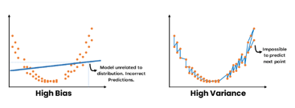

## Trees may be weak learners

- Trees use to be sensitive to small changes in training data which lead to very different tree structure.
- This implies predictions are highly variable
- This may be explained because they are *greedy algorithms* making locally optimal decisions at each node without considering the global optimal solution.
  - This can lead to suboptimal splits and ultimately a weaker predictive performance.

## There’s room for improvement

- In many situations trees may be a good option (e.g. for simplicity and interpretability)
- But there are issues that, if solved, may improve performance.
- It is to be noted, too, that these problems are not unique to trees.
  - Other simple models such as linear regression may be considered as weakl learners in may situations.

## The bias-variance trade-off

- When we try to improve weak learners we need to deal with the bias-variance trade-off.

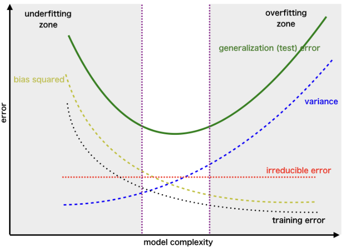

The bias-variance trade-off

## How to deal with such trade-off

- How can a model be made less variable or less biased without this increasing its bias or variance?
- There are distinct appraches to deal with this problem
  - Regularization,
  - Feature engineering,
  - Model selection
  - Ensemble learning

## Ensemble learners

- Ensemble learning takes the approach popularly known as “*the wisdom of crowds*”.
- Predictors, also called, **ensembles** are built by fitting repeated (weak learners) models on the same data and combining them to form a single result.
- Ensemble learners tend to improve the results obtained with the weak learners they are made of.

## Ensemble methods

- If we rely on how they deal with the bias-variance trade-off we can consider distinct groups of ensemble methods:
  - Bagging
  - Boosting
  - Hybrid learners

[Ensemble methods cheatsheet](https://sites.google.com/view/datascience-cheat-sheets#h.t1jchxvxlgr2)

## Aggregating Trees

One type of ensembles is made by constructing multiple trees using different types of subsets.

- **Bagging** (*B*ootstrap *agg*regat*ing*)
  - Random subsets *of observations*.
- **Random Forests** ($\simeq$ Bagging + Feature Selection)
  - Random subsets of observations
  - Random subsets of features at each split

These ensembles reduce variance compared to individual decision trees.

## Boosting & Stacking

- **Boosting** or **Stacking** combine distinct predictors to yield a model with an increasingly smaller error, and so reduce the bias.
- They differ on if do the combination
  - sequentially (1) or
  - using a meta-model (2) .

## Hybrid Techniques

- **Hybrid techniques** combine approaches in order to deal with both variance and bias.
- The approach should be clear from their name:
  - *Gradient Boosted Trees with Bagging*
  - *Stacked bagging*

# Bagging: Aggregating predictors

## Bagging: bootstrap aggregation

- Decision trees suffer from high variance when compared with other methods such as linear regression, especially when $n/p$ is moderately large.
- Given that this is intrinsic to trees, Breiman (1996) sugested to build multiple trees derived from the same dataset and, somehow, average them.

## Averaging decreases variance

- Bagging relies, informally, on the idea that:
  - given $X\sim F()$, s.t. $Var_F(X)=\sigma^2$,
  - given a s.r.s. $X_1, ..., X_n$ from $F$ then
  - if $\overline{X}=\frac{1}{N}\sum_{i=1}^n X_i$ then $var_F(\overline{X})=\sigma^2/n$.
- That is, *relying on the sample mean instead of on simple observations, decreases variance by a factor of $n$*.
- BTW this idea is still (approximately) valid for more general statistics where the CLT applies.

## What means *averaging trees*?

Two questions arise here:

1. How to go from $X$ to $X_1, ..., X_n$?
- This will be done using *bootstrap resampling*.
2. What means “averaging” in this context.
- Depending on the type of tree:
  - Average predictions for regression trees.
  - Majority voting for classification trees.

## *BAGG*ING: Bootstrap Aggregation

- Breiman (1996) combined the ideas of:
  - Averaging provides decreased variance estimates,
  - Bootstrap provides multiple (re)samples.
- He suggested: **b**ootstrap **agg**regat**ing** :
  - Take resamples from the original training dataset
  - Learn the model on each bootstrapped training set
  - Get a prediction ${\small \hat f^{*b}(x)}$ from each model.
- Averaging predictions from single bootstrap models improves single prediction/classification.

## Bagging prediction/classifier

- For regression (trees) the **bagged estimate** is the average prediction at $x$ from these $B$ trees.
  $${\small
  \hat f_{bag}(x)=\frac 1B \sum_{b=1}^B \hat f^{*b}(x)
  }$$
- For classification (trees) the **bagged classifier** selects the class with the most “votes” from the $B$ trees:

$${\small
\hat G_{bag}(x) = \arg \max_k \hat f_{bag}(x).
}$$

## Resampling *based* estimators

- The bootstrap was introduced as a way to provide standard error estimators.
- When used to compute $\hat f_{bag}(x)$ or $\hat G_{bag}(x)$, as described above, it provides direct estimators of a characteristic, not of their standard errors.
- However, the bagging process *can also provide resampling based estimates of the precision of these estimators*.

## Out-Of-Bag observations

- Every time a bootstrap sample is drawn *with replacement*, some observations are not selected.
- For a given tree, these omitted observations are called *out-of-bag* (OOB) observations.
- On average, each bootstrap sample leaves out about one third of the observations: $\left(1-\frac{1}{n}\right)^n \approx e^{-1} \approx 0.368$

## Out-Of-Bag samples

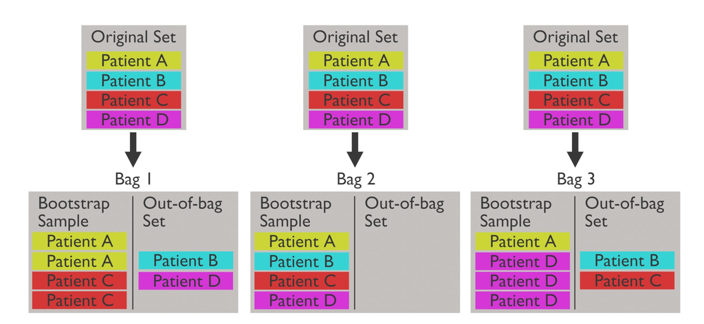

## Out-Of-Bag error estimates (1)

- Since each out-of-bag set is not used to train the model, it can be used to evaluate performance.
- The key idea is that OOB status is defined *for each observation and each tree*.
  - Each tree is trained using its own bootstrap sample.
  - Therefore, each tree has its own OOB observations.
  - For a given observation $i$, we can identify the trees that were trained without using observation $i$.

## Out-Of-Bag error estimates (1)

OOB prediction for observation $i$ is obtained as:

1. Find all trees for which observation $i$ was out-of-bag.
2. Predict $y_i$ using only those trees.
3. Combine these predictions by averaging (regression) or majority vote (classification).
4. Compare OOB prediction with true value $y_i$.
5. Aggregate errors over all observations.

OOB error is an **internal estimate** of the test error.

## Illustration of OOB EE

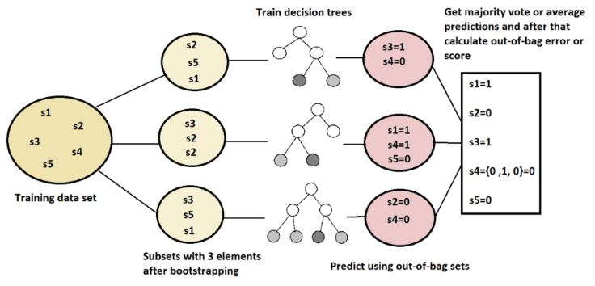

[Source: https://www.baeldung.com/cs/random-forests-out-of-bag-error](https://www.baeldung.com/cs/random-forests-out-of-bag-error)

## Bagging in R

We use the `AmesHousing` dataset on house prices in Ames, IA, to predict the “Sales price” of houses.

1. Start by splitting the dataset in test/train subsets
2. Build a bagged tree on the train subset and evaluate it on the test subset.
3. Interpret the results using “Variable importance”

We use `randomForest` package setting `mtry` to total number of features.

## Bagging - Prepare data

```r
# Prepare "clean" dataset from raw data
ames <- AmesHousing::make_ames()
# Scale response variable to improve readability
ames$Sale_Price <- ames$Sale_Price/1000
# Split in test/training
set.seed(123)
train <- sample(1:nrow(ames), nrow(ames)/2)
# split <- rsample::initial_split(ames, prop = 0.7,
#                        strata = "Sale_Price")
ames_train  <- ames[train,]
ames_test   <- ames[-train,]
```

## Bagging - Build bag of trees

```r
library(randomForest)
set.seed(12543)
bag.Ames <- randomForest(Sale_Price ~ .,
                         data = ames_train,
                         mtry = ncol(ames_train)-1,
                         ntree = 100,
                         importance = TRUE)
```

## Bagging - Results

```r
print(bag.Ames )
```

```
Call:
 randomForest(formula = Sale_Price ~ ., data = ames_train, mtry = ncol(ames_train) -      1, ntree = 100, importance = TRUE)
               Type of random forest: regression
                     Number of trees: 100
No. of variables tried at each split: 80

          Mean of squared residuals: 875.2949
                    % Var explained: 87.28
```

The reported MSE is the OOB estimate of prediction error

[output not shown]

## External test error

Although OOB error provides an internal estimate of prediction error, we can also evaluate performance using an independent test set.

```r
yhat.bag <- predict(bag.Ames, newdata = ames_test)
MSE= mean((yhat.bag -ames_test$Sale_Price)^2)
print(MSE)
```

[output not shown]

- Here, predictions are made on completely unseen observations.
- This is a standard test error estimate, not an OOB estimate.

## Interpetability: The “achiles heel”

- Trees may have a straightforward interpretation,
  - Plotting the tree provides information about
    - which variables are important
    - how they act on the prediction
- Ensembles are less intuitive because
  - there is no consensus tree.
  - not clear which variables are most important.

## Feature importance from Trees

- To measure feature importance, the reduction in the loss function (e.g., SSE) attributed to each variable at each split is tabulated.
- The total reduction in the loss function across all splits by a variable are summed up and used as the total feature importance.

## Feature importance for Ensembles

- Variable importance measures can be extended to an ensemble simply by adding up variable importance over all trees built.

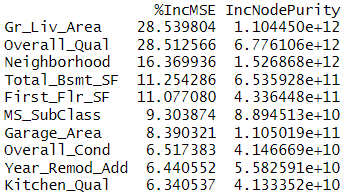